# Beautifying RMarkdown

Antonietta

Mar 29 2021

## The Surprising Truth about `mpg`

### `mpg`: The Figure

Add a code chunk that uses the `ggplot2::mpg` dataset to plot `displ` against `hwy` (highway mpg), with points colored by `manufacturer` and shaped by `year`.

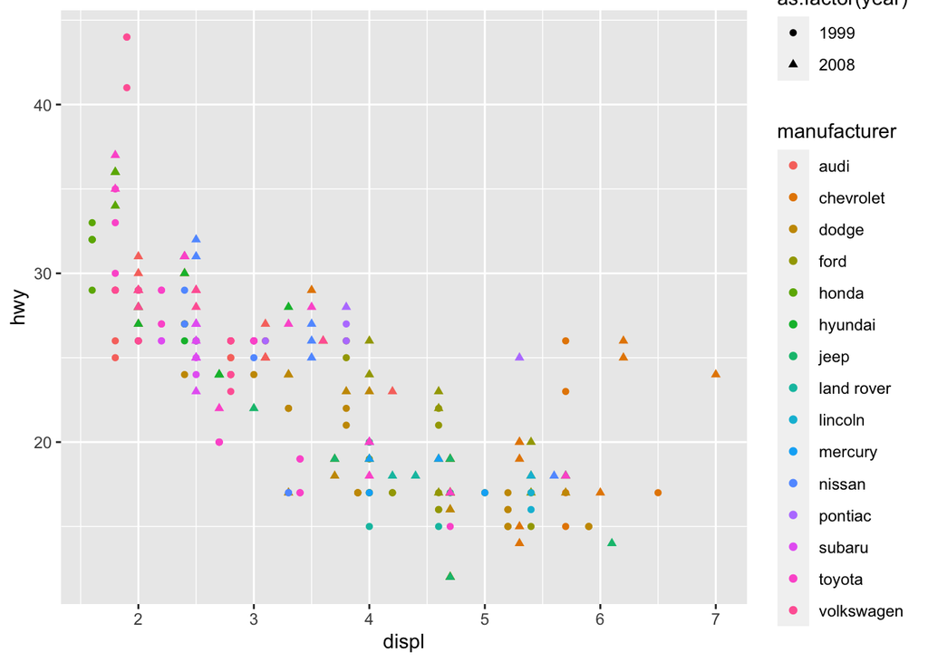

```r
plot_practice <- ggplot2::mpg %>%
  ggplot()+
  aes(x = displ,
      y = hwy,
      fill = manufacturer,
      color = manufacturer,
      shape = as.factor(year)) +
  geom_point()

plot_practice
```

### `mpg`: The Table

Add a second code chunk that gives a summary table with the **mean** and **sd** for `displ` and `hwy` for each year.

```r
summary_table <- ggplot2::mpg%>%
  group_by(year) %>%
  summarize(across(c(displ, hwy),
    list(
    mean = ~mean(.x, na.rm = TRUE),
    sd = ~sd(.x, na.rm = TRUE))))

summary_table
```

```
## # A tibble: 2 x 5
##    year displ_mean displ_sd hwy_mean hwy_sd
## * <int>      <dbl>    <dbl>    <dbl>  <dbl>
## 1  1999       3.28     1.26     23.4   6.08
## 2  2008       3.66     1.30     23.5   5.85
```

Around each piece of output, add a brief description.

We will examine how various options change the rendered HTML output.

## Resources

Here are two general RMarkdown how-to books that are chock-full of great info:

- https://bookdown.org/yihui/rmarkdown/
- https://bookdown.org/yihui/rmarkdown-cookbook/

## Themes

Themes control the general styling of text, headings, etc. RMarkdown comes with several built-in theme options:

- default, cerulean, journal, flatly, darkly, readable, spacelab, united, cosmo, lumen, paper, sandstone, simplex, yeti

You can see how these (and other) themes look [on this page](https://www.datadreaming.org/post/r-markdown-theme-gallery/)

Several packages provide additional themes. Here are a few themes I like:

- hrbrthemes::ipsum
- prettydoc::leonids
- rmdformats::material
- tufte::tufte_html

Change the theme for the document in the YAML header and try out some different themes to see what they look like.

## Code Highlighting

In the RStudio script editor, code syntax is highlighted to make it easier to follow. You can enable this in your knitted output by adding the `highlight` option under the output format.

Available highlighting color schemes include:

- default, tango, pygments, kate, monochrome, espresso, zenburn, haddock, breezedark, textmate, null
- I like `haddock` and `zenburn`
- `null` is the same as omitting `highlight` (disables it)

Add the `highlight` option to the document YAML and try out different styles.

## Code Folding

So far in class, we have always shown both your code and output. This can make it easy to review the code, but makes it hard to read the actual report.

You can have the best of both worlds with the `code_folding` option.

Add the option `code_folding` under your `html_document` output format and set it to `hide`. Knit and see what happens.

You can set all of the code chunks to show initially but still by hideable by setting the option to `show`.

## Table of Contents

You can add a table of contents sidebar to your HTML output by adding the `toc: true` option under your `html_document` output format.

You can set the table of contents to float with the page as the reader scrolls with the `toc_float: true` option. You can control how many levels of headings (`#`, `##`, `###`, etc.) to include in the table of contents with the `toc_depth` option.

Add a floating table of contents to your document and have it show 3 levels of headings. Change the depth to 2 and knit again to see the difference.

## Running R Code in YAML

You can include R code in your YAML that will be evaluated when you knit the document. Do that by writing (in quotes), for example:

- ‘3’ where `1 + 2` is the R code you want to run
- (if you are looking at this in the knit HTML, that’s `` '`r 1 + 2`' ``)

Change the `date` field in YAML to be dynamically generated with today’s date by running this R expression in the `date` field:

```r
format(Sys.Date(), '%b %d %Y')
```

**Note!** For some parts of your YAML, this syntax doesn’t work. In those cases, use this alternative format:

- `'!expr <expression>'`

## Chunk Options

YAML options let you control output features for the whole document. You can also specify options to control output of each code chunk. For example, you can control the size of images or set a chunk not to run.

Set chunk options like this:

```
{r chunk name, option=TRUE, option="choice"}
```

We will practice a few useful chunk options. For more details, see https://yihui.org/knitr/options/.

### Chunk Names

You can give your chunks names. This is helpful if you want to keep track of where in your document the knitting process is as it runs (useful if you have a long script that takes some time to run). Anything after the `r` in the chunk heading before the first comma will be the chunk name.

Chunk names have to be unique (not duplicated) by default, so be careful when copying and pasting chunks in your document.

You should always have a chunk at the top of your script called `setup`. In this script, you should have:

- All of your `library()` calls or other package checks
- Other options or “setup” bits (e.g., vectors of item names for scales).
- Potentially, put your data import calls here.

RStudio treats the `setup` chunk a little specially. When you run chunks interactively (by clicking the Run buttons or typing Ctrl+Enter or Cmd+Return), RStudio will run the `setup` chunk first.

### eval, echo, include

These chunk options control whether a chunk is run and whether the code and output are shown.

- `eval`: Should the code be run (evaluated)? Set to `FALSE` to not run the code
  - e.g., use this if you include an `install.packages()` call in your script
- `echo`: Should the code be included? Set to `FALSE` to omit the code.
  - Note that if you have code folding enabled, `echo=FALSE` will still remove the code entirely.
- `include`: Should the output be included. Set to `FALSE` to omit the output
  - This is useful, for example, to hide output of `library()` calls from your `setup` chunk.

Try these out!

### fig.width, fig.height

You can control height and width of figures in a chunk (in inches) with `fig.width` and `fig.height`.

Change your plot chunk’s figure dimensions and see what happens.

### Graphic Device and DPI

By default, RMarkdown will save images as PNG (a bitmap format). You can change this to use SVG or PDF using the `dev` option: `dev="svglite"` or `dev="pdf"`

For bitmap devices, you can specify the resolution (DPI) for images with the `dpi` argument. For example, `dpi=300`. This mostly doesn’t matter for HTML output, but if you output to Word or PDF, you will want to specify a DPI of 300.

Try changing the graphics device for your plot chunk to `"svglite"`.

### Caching

Be careful with caching! This approach only checks if the code in a specific chunk has changed. It won’t work correctly if, e.g., you have changed a data file that is read in or if you change a variable from a previous chunk that the current chunk relies on.

You almost always want to set caching on specific chunks, rather than globally. We will explore some more robust caching methods in a future class.

### Allowing Errors

Normally, if your R code produces an error, knitting will stop. If you want to allow knitting to continue even if there’s an error, set the `error=TRUE` option.

Try it out! Change this chunk’s `eval=FALSE` to `error=TRUE`.

```r
stop("This is a scary error!")
```

### Collapsing Results Together

Normally, if both `echo` and `include` are `TRUE`, if a chunk has multiple outputs, the knitted document will alternate `code 1`, `output 1`, `code 2`, `output 2`, etc. If you want to have to show all of the code together, then all of the outputs together, set the `collapse` chunk option to `TRUE`.

### result= ‘asis’

Some packages generate output text that is already in HMTL, LaTeX, or Markdown format and doesn’t need any more processing. To render such output, set the `results` option to ‘asis’.

Try it out! Add results=‘asis’ to this chunk and see how the output changes.

```r
cat("$$
\\operatorname{mpg} = \\alpha + \\beta_{1}(\\operatorname{cyl}) + \\beta_{2}(\\operatorname{disp}) + \\epsilon
$$")
```

$$\operatorname{mpg} = \alpha + \beta_{1}(\operatorname{cyl}) + \beta_{2}(\operatorname{disp}) + \epsilon$$

### Global vs Specific Chunk Options

If you set a chunk both globally and on a specific chunk, the specific setting will override the global setting for that chunk.

## A Few More Awesome Things

Let’s look at a few more awesome RMarkdown features we can explore.

### params

You can set parameters for your document that you can call later. Do this by adding a `params` option to the first-indentation level of your document YAML. Add parameters as options indented under `params` like this:

```
title: "Your document title"
params:
  manufacturer: "audi"
```

You can refer to a parameter with the code `params$paramter` (e.g., `params$manufacturer`).

Try it! Add `manufacturer: "audi"` as a parameter to your document. Then, filter the `mpg` data to only show cars with this manufacturer before creating the plot.

### Tables

By default, if you just print a data frame, it will be formatted in your document the same way it is in the R console. This isn’t ideal.

You can format the document in a nicer way with the `knitr::kable()` function. For very long tables in HTML output, the `DT::datatable()` function is better.

We will also explore more advanced table design packages in a future class.

Try it! Change your table output above to use the `knitr::kable()` function. Then, knit and see the difference.

### Tabbed Results

If you have a long document, it can be hard to navigate. One way you can help organize your document is with tabs.

You can specify a section to be tabbed by adding `{.tabset}` at the end of the heading line. Then, all of the sub-headings on the next level below that one will be formatted as tabs.

### Hidden `<details>`

You can hide a secontion of your document behind a clickable button (like code folding) with the HTML `<details>` tag. When something is inside a `<details> </details>` block, it won’t show until the button is clicked.

You can add a title describing what’s behind the button with the `<summary>` tag.

For example:

```
<details>
  <summary>This is the title of the hidden code.</summary>
  This text doesn't show until the button is clicked.
</details>
```

One really useful use of `<details>` is to provide the information about your computer system and the versions of packages you used at the end of your document with `devtools::session_info()`.

Try it! Add a `<details>` block to the end of the document that contains a code chunk with `devtools::session_info()` in it. Provide an appropriate `<summary>` for the `<details>`.

### Other Child Scripts and Documents

You can offload some parts of your script to different documents. For example, you could move your data cleaning steps to a separate `.R` document. You could also move different chapters of your document (e.g., of your thesis) to separate `.Rmd` documents. We will explore this in a future class.

## Word documents

We are usally working with HTML documents. HTML is a great format because it is small and handles page formatting for you. It’s a great default format, especially if readers will read on screen.

Sometimes you might want to work with Word, though. For example, I often write my main document in Word, but write the methods and results sections and tables and figures with RMarkdown. Then, I copy-paste those in one go into the Word document.

Let’s try out some Word knitting options.

Add `word_document: default` as an output format for your document and knit it. Look at the resulting Word file.

### Template Files

The default Word template styles used are pretty ugly in my opinion. You can provide RMarkdown with a different template file.

### Page Breaks

In HTML, you don’t need to worry about page breaks. In Word or PDF, you might want to force a page break so that some content (e.g., the next table) starts on a new page.

To do that, add `\newpage` to your Markdown text on its own line (with a blank line before and after).

Try it! Add a page break between your plot and your table output. Then, knit and see what happens.

### Options Based on Output Format

You might want to change your chunk options based on your output format. For example, you might want to include folded code chunks if your document is knit to HTML but omit them if going to Word (where code folding doesn’t exist).

To do that, you can use the `knitr::is_html_output()` or `knitr::pandoc_to()` functions. `knitr::is_html_output()` will return `TRUE` if knitting to an HTML-like format (e.g., HTML or Markdown) and `FALSE` otherwise. `knitr::pandoc_to()` takes a character vector of file extensions (e.g., `"docx"` for Word) and checks if the document is knitted to that format.

Try it! Change the `echo` option for your chunks to be `echo=knitr::is_html_output()`, then knit to Word and see the result!